# STAT545 HW06

# 1 Character data

To work with strings, first we should load the libraries.

```r
library(tidyverse)
library(stringr)
```

Then after finished the strings chapter, we can begin to work on exercises.

## 1.1 Exercises 14.2.5

1. In code that doesn’t use stringr, you’ll often see `paste()` and `paste0()`. What’s the difference between the two functions? What stringr function are they equivalent to? How do the functions differ in their handling of `NA`?

```r
paste("stat", "545")
```

```
## [1] "stat 545"
```

```r
paste0("stat", "545")
```

```
## [1] "stat545"
```

```r
str_c("stat", NA)
```

```
## [1] NA
```

```r
paste("stat", NA)
```

```
## [1] "stat NA"
```

With `paste` you can specify a `sep` argument to seperate the strings. But with `paste0`, the `sep` argument is fixed to nothing. The corresponding stringr function is `str_c`. `str_c` will output `NA` if there is a `NA` in the middle, and `paste` will convert `NA` to a string “NA” and then do the `paste`.

2. In your own words, describe the difference between the `sep` and `collapse` arguments to `str_c()`.

```r
str_c("stat", "545", c(101, 102), sep = " ")
```

```
## [1] "stat 545 101" "stat 545 102"
```

```r
str_c("stat", "545", c(101, 102), sep = " ", collapse = ",")
```

```
## [1] "stat 545 101,stat 545 102"
```

`sep` argument seperates the strings to be merged, and with `collapse` the returned vector is merged again with `collapse` argument in between.

3. Use `str_length()` and `str_sub()` to extract the middle character from a string. What will you do if the string has an even number of characters?

```r
x <- "abcdef"
str_sub(x, str_length(x)/2+1, str_length(x)/2+1)
```

```
## [1] "d"
```

If the string has an even number of characters, this will select the latter one of the middle two characters.

4. What does `str_wrap()` do? When might you want to use it?

```r
txt <- "What does `str_wrap()` do? When might you want to use it?"
cat(str_wrap(txt, width = 40, indent = 2))
```

```
##   What does `str_wrap()` do? When might
## you want to use it?
```

`str_wrap` takes the input string and output a print format string with line width constrain. When you want to write to a text file, you may want to use it.

5. What does `str_trim()` do? What’s the opposite of `str_trim()`?

```r
txt <- "  What does `str_wrap()` do? When might you want to use it?  "
str_trim(txt)
```

```
## [1] "What does `str_wrap()` do? When might you want to use it?"
```

```r
str_pad(txt, 70, side = "both")
```

```
## [1] "      What does `str_wrap()` do? When might you want to use it?       "
```

`str_trim` removes white spaces from one or both sides of the string. `str_pad` pads the string to some width with argument `pad`, and defaultly it is set to white space.

6. Write a function that turns (e.g.) a vector `c("a", "b", "c")` into the string `a, b, and c`. Think carefully about what it should do if given a vector of length 0, 1, or 2.

```r
vector_3 <- c("a", "b", "c")
vector_2 <- c("a", "b")
vector_1 <- c("a")
vector_0 <- c()
and <- function(v) {
  len <- length(v)
  if (len %in% c(0, 1)) return(v)
  if (len == 2) return(str_c(v, collapse = " and "))
  v[len] <- paste("and ", v[len])
  str_c(v, collapse = ", ")
}
and(vector_0)
```

```r
and(vector_1)
```

```
## [1] "a"
```

```r
and(vector_2)
```

```
## [1] "a and b"
```

```r
and(vector_3)
```

```
## [1] "a, b, and  c"
```

## 1.2 Exercises 14.3.1.1

1. Explain why each of these strings don’t match a `\`: `"\"`, `"\\"`, `"\\\"`.

```r
x <- "a\\b"
str_view(x, "\\\\")
```

[interactive chart not shown]

`"\"` is not a legal string, because `\"` would be one character, and same with `"\\\"`. `"\\"` is single `\` in the string, and when you make a string again, it goes back to `"\"` case.

2. How would you match the sequence `"'\`?

```r
x <- "a\"\'\\b"
str_view(x, "\"\'\\\\")
```

[interactive chart not shown]

3. What patterns will the regular expression `\..\..\..` match? How would you represent it as a string?

This matches dot splited 3 characters, like `".a.b.c"`. The string representation would be `"\\..\\..\\.."`.

## 1.3 Exercises 14.3.2.1

1. How would you match the literal string `"$^$"`?

```r
x <- "$^$"
str_view(x, "\\$\\^\\$")
```

[interactive chart not shown]

2. Given the corpus of common words in `stringr::words`, create regular expressions that find all words that:
- Start with “y”.
- End with “x”
- Are exactly three letters long. (Don’t cheat by using `str_length()`!)
- Have seven letters or more. Since this list is long, you might want to use the ‘match’ argument to ‘str_view()’ to show only the matching or non-matching words.

```r
str_view(stringr::words, "^y", match = TRUE)
```

[interactive chart not shown]

```r
str_view(stringr::words, "x$", match = TRUE)
```

[interactive chart not shown]

```r
str_view(stringr::words, "^.{3}$", match = TRUE)
```

[interactive chart not shown]

```r
str_view(stringr::words, "^.{7,}$", match = TRUE)
```

[interactive chart not shown]

## 1.4 Exercises 14.3.3.1

1. Create regular expressions to find all words that:
- Start with a vowel.
- That only contain consonants. (Hint: thinking about matching “not”-vowels.)
- End with `ed`, but not with `eed`.
- End with `ing` or `ise`.

```r
str_view(stringr::words, "^[aeiou]", match = TRUE)
```

[interactive chart not shown]

```r
str_view(stringr::words, "^[^aeiou]*$", match = TRUE)
```

[interactive chart not shown]

```r
str_view(stringr::words, "[^e]ed$", match = TRUE)
```

[interactive chart not shown]

```r
str_view(stringr::words, "ing$|ise$", match = TRUE)
```

[interactive chart not shown]

2. Empirically verify the rule “i before e except after c”.

```r
str_view(stringr::words, "[^c]ie", match = TRUE)
```

[interactive chart not shown]

3. Is “q” always followed by a “u”?

```r
str_view(stringr::words, "q[^u]", match = TRUE)
```

[interactive chart not shown]

Yes, it is.

4. Write a regular expression that matches a word if it’s probably written in British English, not American English.

```r
str_view(stringr::words, "our$", match = TRUE)
```

[interactive chart not shown]

5. Create a regular expression that will match telephone numbers as commonly written in your country.

```r
str_view("123(456)7890", "\\d{3}\\(\\d{3}\\)\\d{4}")
```

[interactive chart not shown]

## 1.5 Exercises 14.3.4.1

1. Describe the equivalents of `?`, `+`, `*` in `{m,n}` form.

`?` equals `{0,1}`. `+` equals `{1,}`. `*` equals `{0,}`.

2. Describe in words what these regular expressions match: (read carefully to see if I’m using a regular expression or a string that defines a regular expression.)
- `^.*$` matches strings that start without `"\n"` and `"\r"`.
- `"\\{.+\\}"` matches a brace with some charactors in between.
- `\d{4}-\d{2}-\d{2}` matches something like a date, for example “2018-01-01”.
- `"\\\\{4}"` matches four `\` in a row.
3. Create regular expressions to find all words that:
- Start with three consonants.
- Have three or more vowels in a row.
- Have two or more vowel-consonant pairs in a row.

```r
str_view(stringr::words, "^[^aeiou]{3}", match = TRUE)
```

[interactive chart not shown]

```r
str_view(stringr::words, "[aeiou]{3,}", match = TRUE)
```

[interactive chart not shown]

```r
str_view(stringr::words, "([aeiou][^aeiou]){2,}", match = TRUE)
```

[interactive chart not shown]

4. Solve the beginner regexp crosswords at https://regexcrossword.com/challenges/beginner.

## 1.6 Exercises 14.3.5.1

1. Describe, in words, what these expressions will match:
- `(.)\1\1` matches three same characters in a row.
- `"(.)(.)\\2\\1"` matches two same characters with other two same characters in between, for example “abba”.
- `(..)\1` matches two characters repeat twice, for example “abab”.
- `"(.).\\1.\\1"` matches three same characters with other two characters in between, for example “abaca”.
- `"(.)(.)(.).*\\3\\2\\1"` matches something like “abc1234abcdcba”.
2. Construct regular expressions to match words that:
- Start and end with the same character.
- Contain a repeated pair of letters (e.g. “church” contains “ch” repeated twice.)
- Contain one letter repeated in at least three places (e.g. “eleven” contains three “e”s.)

```r
str_view(stringr::words, "^(.).*\\1$", match = TRUE)
```

[interactive chart not shown]

```r
str_view(stringr::words, "^(..).*\\1.*$", match = TRUE)
```

[interactive chart not shown]

```r
str_view(stringr::words, "^.*(.).*(\\1.*){2,}$", match = TRUE)
```

[interactive chart not shown]

## 1.7 Exercises 14.4.2

1. For each of the following challenges, try solving it by using both a single regular expression, and a combination of multiple `str_detect()` calls.
- Find all words that start or end with `x`.
- Find all words that start with a vowel and end with a consonant.
- Are there any words that contain at least one of each different vowel?

```r
str_view(stringr::words, "^x|x$", match = TRUE)
```

[interactive chart not shown]

```r
str_view(stringr::words, "^[aeiou].*[^aeiou]$", match = TRUE)
```

[interactive chart not shown]

```r
str_view(stringr::words, "(?=.*a)(?=.*e)(?=.*i)(?=.*o)(?=.*u)", match = TRUE)
```

[interactive chart not shown]

```r
words <- tibble(
  words = stringr::words
)

words %>%
  filter(str_detect(words, "^x|x$"))
```

```
## # A tibble: 4 x 1
##   words
##   <chr>
## 1 box
## 2 sex
## 3 six
## 4 tax
```

```r
words %>%
  filter(str_detect(words, "^[aeiou].*[^aeiou]$"))
```

```
## # A tibble: 122 x 1
##    words
##    <chr>
##  1 about
##  2 accept
##  3 account
##  4 across
##  5 act
##  6 actual
##  7 add
##  8 address
##  9 admit
## 10 affect
## # ... with 112 more rows
```

```r
words %>%
  filter(str_detect(words, "(?=.*a)(?=.*e)(?=.*i)(?=.*o)(?=.*u)"))
```

```
## # A tibble: 0 x 1
## # ... with 1 variable: words <chr>
```

2. What word has the highest number of vowels? What word has the highest proportion of vowels? (Hint: what is the denominator?)

```r
words <- words %>%
  mutate(
    vowels = str_count(words, "[aeiou]"),
    proportion = str_count(words, "[aeiou]") / str_count(words, ".")
  )

words %>%
  arrange(desc(vowels)) %>%
  head()
```

```
## # A tibble: 6 x 3
##   words       vowels proportion
##   <chr>        <int>      <dbl>
## 1 appropriate      5      0.455
## 2 associate        5      0.556
## 3 available        5      0.556
## 4 colleague        5      0.556
## 5 encourage        5      0.556
## 6 experience       5      0.5
```

```r
words %>%
  arrange(desc(proportion)) %>%
  head()
```

```
## # A tibble: 6 x 3
##   words vowels proportion
##   <chr>  <int>      <dbl>
## 1 a          1      1
## 2 area       3      0.75
## 3 idea       3      0.75
## 4 age        2      0.667
## 5 ago        2      0.667
## 6 air        2      0.667
```

## 1.8 Exercises 14.4.3.1

1. In the previous example, you might have noticed that the regular expression matched “flickered”, which is not a colour. Modify the regex to fix the problem.

```r
colours <- c("red", "orange", "yellow", "green", "blue", "purple")
colour_match <- str_c("\\s", colours, collapse = "|")
more <- sentences[str_count(sentences, colour_match) > 1]
str_view_all(more, colour_match)
```

[interactive chart not shown]

2. From the Harvard sentences data, extract:
- The first word from each sentence.
- All words ending in `ing`.
- All plurals.

```r
str_view_all(sentences, "^.*?\\s")
```

[interactive chart not shown]

```r
str_view_all(sentences, "\\w*ing\\s", match = TRUE)
```

[interactive chart not shown]

```r
str_view_all(sentences, "es\\s", match = TRUE)
```

[interactive chart not shown]

## 1.9 Exercises 14.4.4.1

1. Find all words that come after a “number” like “one”, “two”, “three” etc. Pull out both the number and the word.

```r
noun <- "\\s(one|two|three)\\s*\\w+"
has_num <- sentences %>%
  str_subset(noun)
has_num %>%
  str_extract(noun)
```

```
##  [1] " two met"       " two factors"   " three lists"   " two when"
##  [5] " one war"       " one button"    " two shares"    " two distinct"
##  [9] " two pins"      " three story"   " three inches"  " three batches"
## [13] " two leaves"
```

2. Find all contractions. Separate out the pieces before and after the apostrophe.

```r
con <- "\\w*\'\\w*"
has_con <- sentences %>%
  str_subset(con)
has_con %>%
  str_extract(con)
```

```
##  [1] "It's"       "man's"      "don't"      "store's"    "workmen's"
##  [6] "Let's"      "sun's"      "child's"    "king's"     "It's"
## [11] "don't"      "queen's"    "don't"      "pirate's"   "neighbor's"
```

## 1.10 Exercises 14.4.5.1

1. Replace all forward slashes in a string with backslashes.

```r
x <- "\\\\a//b\\c///d\\\\"
str_replace_all(x, "\\\\", "/")
```

```
## [1] "//a//b/c///d//"
```

2. Implement a simple version of `str_to_lower()` using `replace_all()`.

```r
x <- "AaBbCcDd"
names(letters) <- LETTERS
str_replace_all(x, letters)
```

```
## [1] "aabbccdd"
```

3. Switch the first and last letters in `words`. Which of those strings are still words?

```r
str_replace_all(stringr::words, "(\\w)(\\w*)(\\w)", "\\3\\2\\1") %>% head()
```

```
## [1] "a"        "ebla"     "tboua"    "ebsoluta" "tccepa"   "tccouna"
```

## 1.11 Exercises 14.4.6.1

1. Split up a string like `"apples, pears, and bananas"` into individual components.

```r
x <- "apples, pears, and bananas"
str_split(x, "(, and )|(, )")
```

```
## [[1]]
## [1] "apples"  "pears"   "bananas"
```

2. Why is it better to split up by `boundary("word")` than " "?

```r
str_split(x, " ")
```

```
## [[1]]
## [1] "apples," "pears,"  "and"     "bananas"
```

```r
str_split(x, boundary("word"))
```

```
## [[1]]
## [1] "apples"  "pears"   "and"     "bananas"
```

`boundary` can automatically remove white spaces and other signs, including comma and dot.

3. What does splitting with an empty `string ("")` do? Experiment, and then read the documentation.

```r
str_split(x, "")
```

```
## [[1]]
##  [1] "a" "p" "p" "l" "e" "s" "," " " "p" "e" "a" "r" "s" "," " " "a" "n"
## [18] "d" " " "b" "a" "n" "a" "n" "a" "s"
```

It splits the string into characters.

## 1.12 Exercises 14.5.1

1. How would you find all strings containing `\` with `regex()` vs. with `fixed()`?

```r
x <- "\\\\a//b\\c///d\\\\"
str_view_all(x, regex("\\\\"))
```

[interactive chart not shown]

```r
str_view_all(x, fixed("\\"))
```

[interactive chart not shown]

2. What are the five most common words in `sentences`?

```r
words_in_s <-
  str_split(sentences, boundary("word")) %>%
  unlist() %>%
  str_to_lower()
as.data.frame(table(words_in_s)) %>%
  arrange(desc(Freq)) %>%
  head(5)
```

```
##   words_in_s Freq
## 1        the  751
## 2          a  202
## 3         of  132
## 4         to  123
## 5        and  118
```

## 1.13 Exercises 14.7.1

1. Find the stringi functions that:
- Count the number of words. `stringi::stri_count_words()`
- Find duplicated strings. `stringi::stri_duplicated()`
- Generate random text. `stringi::stri_rand_strings()`
2. How do you control the language that `stri_sort()` uses for sorting?

By `locale` argument. For example:

`stri_sort(c("hladny", "chladny"), locale="sk_SK")`

# 2 Write function

Write one (or more) functions that do something useful to pieces of the Gapminder or Singer data. It is logical to think about computing on the mini-data frames corresponding to the data for each specific country, location, year, band, album, … This would pair well with the prompt below about working with a nested data frame, as you could apply your function there.

Make it something you can’t easily do with built-in functions. Make it something that’s not trivial to do with the simple dplyr verbs. The linear regression function presented here is a good starting point. You could generalize that to do quadratic regression (include a squared term) or use robust regression, using `MASS::rlm()` or `robustbase::lmrob()`.

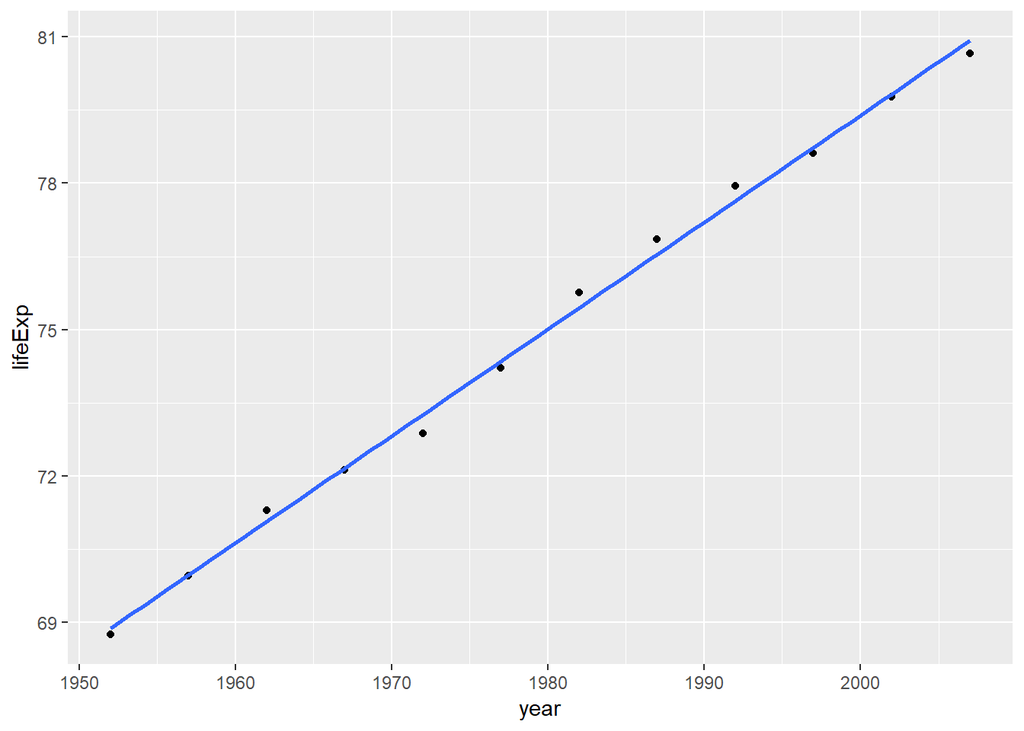

```r
library(gapminder)
gap_cad <- gapminder %>%
  filter(country == "Canada") %>%
  mutate(
    year_m = year - 1952
  )
p <- ggplot(gap_cad, aes(x = year, y = lifeExp))
p + geom_point() + geom_smooth(method = "lm", se = FALSE)
```

`le_qua_fit` is a function for quadratic regression. We can see that for countries like Zimbabwe, it is a better fit than the linear regression.

```r
le_lin_fit <- function(dat, offset = 1952) {
  the_fit <- lm(lifeExp ~ I(year - offset), dat)
  setNames(coef(the_fit), c("intercept", "slope"))
}

le_qua_fit <- function(dat, offset = 1952) {
  the_fit <- lm(lifeExp ~ poly(year - offset, 2, raw = TRUE), dat)
  setNames(coef(the_fit), c("intercept", "poly 1", "poly 2"))
}

gap_zim <- gapminder %>% filter(country == "Zimbabwe")
(model_lin <- le_lin_fit(gap_zim))
```

```
##   intercept       slope
## 55.22124359 -0.09302098
```

```r
(model_qua <- le_qua_fit(gap_zim))
```

```
##   intercept      poly 1      poly 2
## 45.69740659  1.04983946 -0.02077928
```

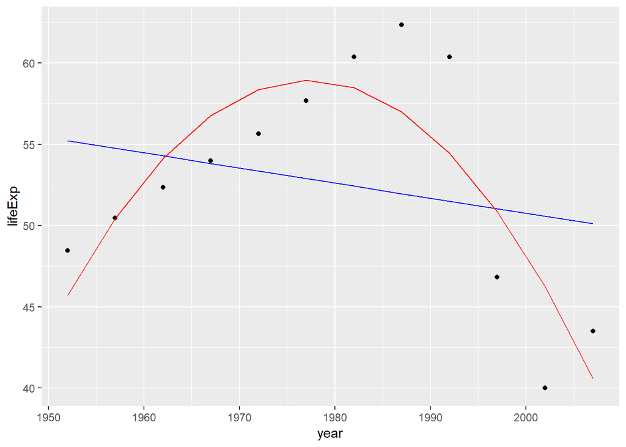

```r
years = seq(1952, 2007, 5)
le_fit = tibble(
  year = years,
  le_lin = model_lin[1] + (years - 1952) * model_lin[2],
  le_qua = model_qua[1] + (years - 1952) * model_qua[2] + (years - 1952)^2 * model_qua[3]
)

ggplot(gap_zim, aes(x = year, y = lifeExp)) +
  geom_point() +
  geom_line(aes(x = year, y = le_lin), le_fit, color = "blue") +
  geom_line(aes(x = year, y = le_qua), le_fit, color = "red")
```